# A3: Panel Simulation/DiD

Havisha Khurana

2025-02-14

```r
library(tidyverse)
library(estimatr)
```

**Part 1.** Code up a DGP in which there are $n_t$ observations of $n_i$ individual economic agents (*i.e.*, an $n_i \times n_t$ panel). Within this panel, allow some but not all $i$ to be treated. For now, assume that treatment falls in the middle of the time series, at the same $t$ for each treated unit—once treatment arrives, let’s have treatment stay on for the rest of the time series (for now, anyway). Likewise, have all $i$ trend similarly through the time series. (*You should recognize that this is all sounding fairly well behaved—the sort of environment in which we would expect to be able to identify the causal parameter.*) Here’s the twist. As part of this DGP, I don’t want you to hardwire $i$ specific trends to be common—instead, have each cross-sectional unit draw their trend from a $N(0,\sigma)$ distribution. In this way, we would expect that they would be trending similarly on average, but we could questions this somewhat. (*Hence, parameterize the variance so you can consider its role.*)

**The DGP:**

```r
# description of parameters
# difference between treatment and control group: beta_x = 1
# diff between treated and untreated period: beta_tr = 0
# effect of treatment in treated period: beta_xtr = 1
# effect of time/year - linear: beta_t = 0
# heterogeneous effect of time in treated period: beta_ttr = 0
# effect of cluster-level variable: beta_cx = 0

simulate_panel <- function(seed = 1, n_i, n_c, n_t){

cross <- tibble(
    i = 1:n_i,
    # assignment to treatment
    x = rep(0:1, each = n_i/2),
    # cluster in which y belongs
    c = sample(1:n_c,size = n_i, replace = T),
    # length of the panel
    t_length = n_t,
    # individual-level error term
    ei = rnorm(length(1:n_i), 0, 1)
)

cluster <- tibble(
    c = 1:n_c,
    # cluster-level variable
    cx = rnorm(n_c),
    # cluster-level error term
    ec = rnorm(length(1:n_c), 0, 1)
)

year <- tibble(
    t = 1:n_t,
    # year-level error term
    et = rnorm(length(1:n_t), 0, 1)
)

panel <- plyr::ddply(cross, ~i, transform, t = 1:t_length) %>%
  left_join(cluster, by = "c") %>%
  left_join(year, by = "t") %>%
  mutate(
    eit = rnorm(length(1:(n_i*n_t)), 0, 1),
    tr = ifelse(t>=n_t/2, 1, 0),
    xtr = x*tr,
     # with four error terms and only x and xtr turned on
    y1 = 10 + 1*x + 0*tr + 1*xtr + 0*t + 0*t*tr + 0*cx + eit + et + ei + ec,
    # with tr turned on
    y2 = 10 + 1*x + 1*tr + 1*xtr + 0*t + 0*t*tr + 0*cx + eit + et + ei + ec,
    # with t turned on
    y3 = 10 + 1*x + 0*tr + 1*xtr + 1*t + 0*t*tr + 0*cx + eit + et + ei + ec,
    # with t*tr turned on
    y4 = 10 + 1*x + 0*tr + 1*xtr + 0*t + 1*t*tr + 0*cx + eit + et + ei + ec,
    # with cx turned on
    y5 = 10 + 1*x + 0*tr + 1*xtr + 0*t + 0*t*tr + 1*cx + eit + et + ei + ec,
    # with all things turned on
    y6 = 10 + 1*x + 1*tr + 1*xtr + 1*t + 1*t*tr + 1*cx + eit + et + ei + ec
  )

return(panel)
}
```

**Part 2:** Plot a representative iteration of the above DGP, clearly demonstrating (i) where treatment falls and (ii) which observations are part of the treatment group and which are part of the control groups. (*I’m asking for the classic DiD plot, showing trends across time and any level shift induced by treatment.*)

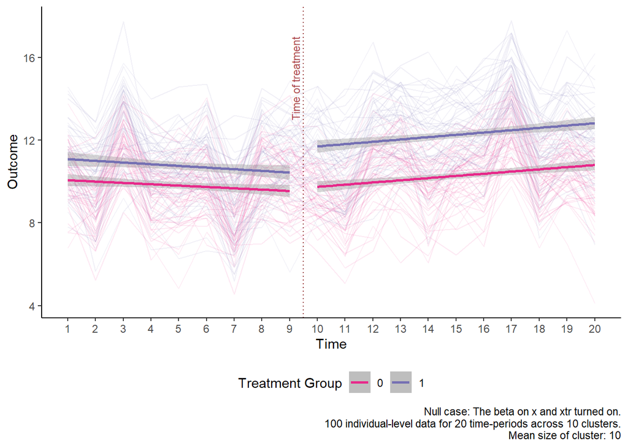

```r
# setting time, individual, cluster parameters (n)
n_t <- 20
n_i <- 100
n_c <- 10

panel <- simulate_panel(n_i = n_i, n_c = n_c, n_t = n_t)

gen_did_plot <- function(df, y_outcome, caption){

  plot <- ggplot(df, aes(x = t, y = {{y_outcome}}, color = factor(x))) +
  geom_line(aes(group = i), alpha = 0.1) +
  geom_smooth(data = filter(panel, t < n_t/2), method = "lm", linewidth = 1) +
  geom_smooth(data = filter(panel, t >= n_t/2), method = "lm", linewidth = 1) +
  labs(
    x = "Time",
    y = "Outcome",
    color = "Treatment Group",
    caption = paste0(caption,
                    "\n", max(df$i)," individual-level data for ",max(df$t)," time-periods across ",max(df$c)," clusters.\nMean size of cluster: ",mean(table(df$c)/n_t)
)
  ) +
  scale_x_continuous(breaks = 1:n_t)+
  geom_vline(aes(xintercept = (n_t-1)/2), color = "darkred", linetype = "dotted")+
  annotate(geom = "text", x = n_t/2 - 0.8, y = 15, label = "Time of treatment",color = "darkred", angle = 90, size = 3, alpha = 0.7)+
  scale_color_manual(values = rev(RColorBrewer::brewer.pal(4, "Dark2"))) +
  theme_classic() +
  theme(legend.position = "bottom") #+
    #scale_y_continuous(limits = c(0,20))

  plot
}


gen_did_plot(panel, y1, caption = "Null case: The beta on x and xtr turned on.")
```

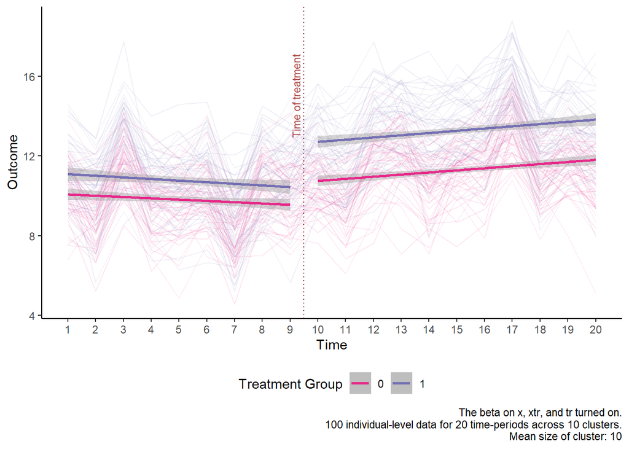

```r
gen_did_plot(panel, y2, caption = "The beta on x, xtr, and tr turned on.")
```

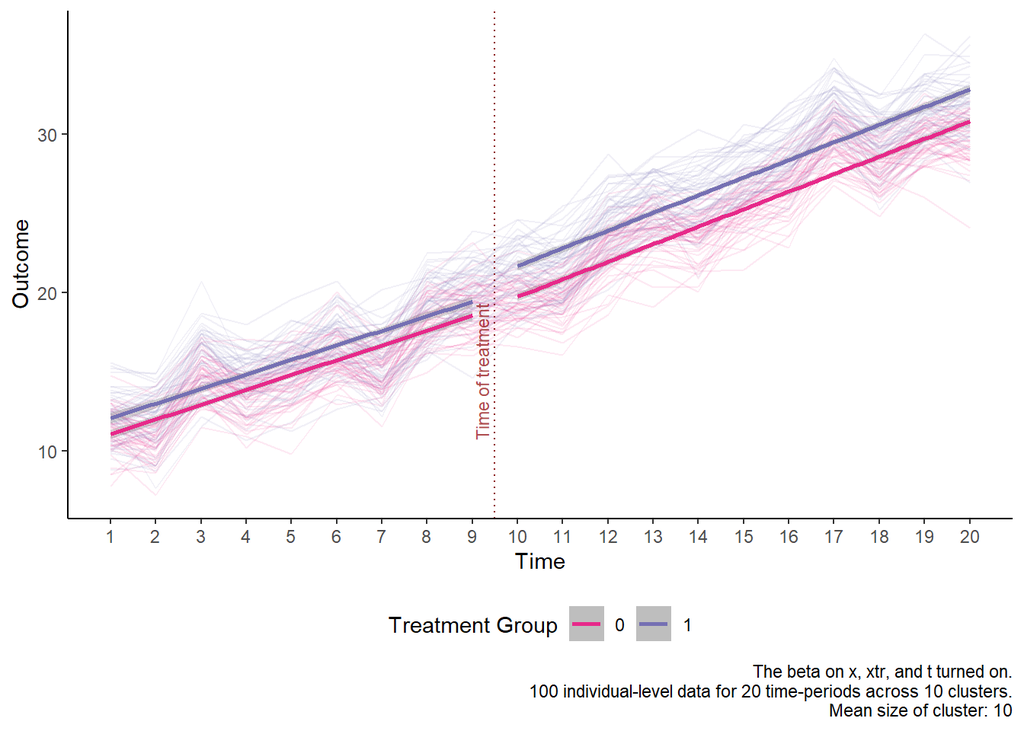

```r
gen_did_plot(panel, y3, caption = "The beta on x, xtr, and t turned on.")
```

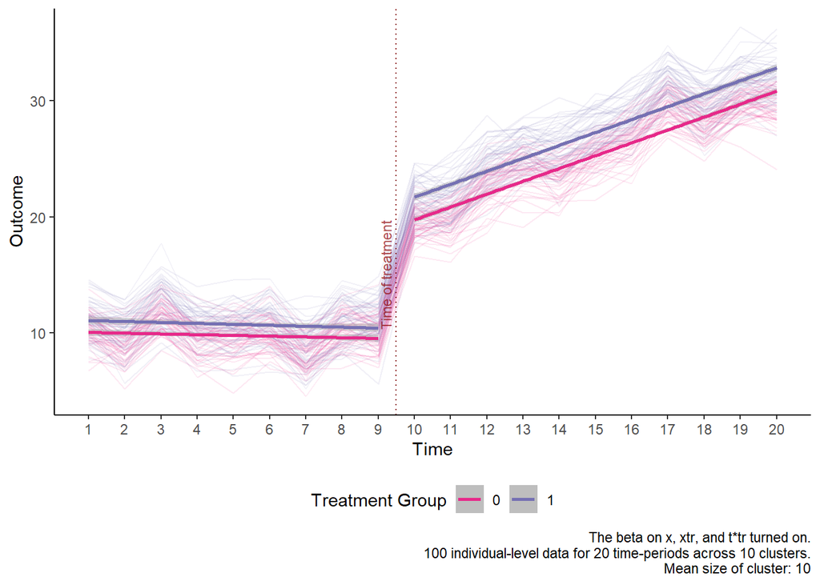

```r
gen_did_plot(panel, y4, caption = "The beta on x, xtr, and t*tr turned on.")
```

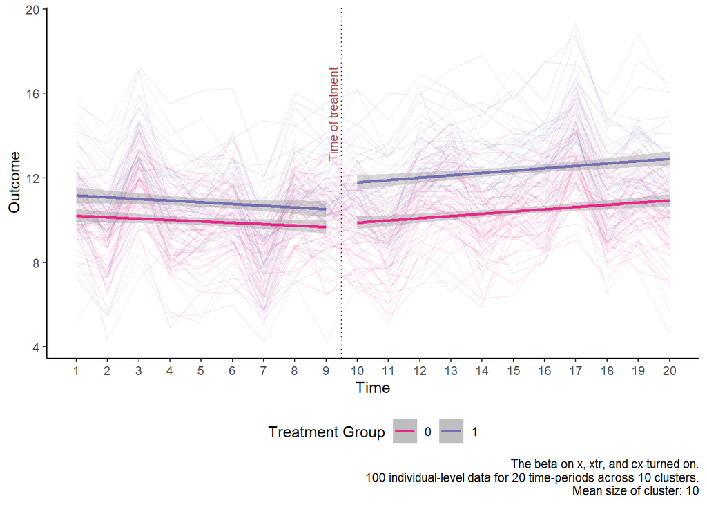

```r
gen_did_plot(panel, y5, caption = "The beta on x, xtr, and cx turned on.")
```

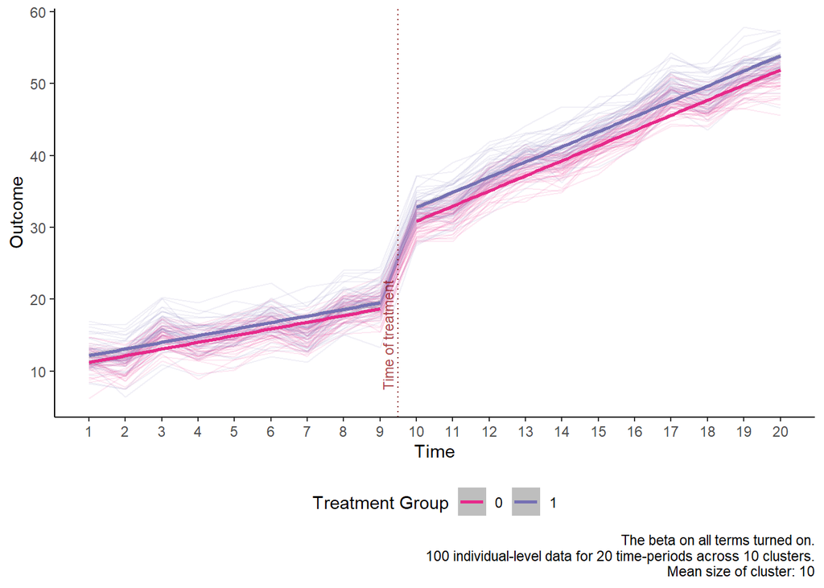

```r
gen_did_plot(panel, y6, caption = "The beta on all terms turned on.")
```

**Part 3.** Simulate this DGP, demonstrating that the distribution of $\hat\beta$ across 500 iterations of your DGP well captures the true $\beta=1$, given the estimating equation,
$$Y_{it}= \alpha_0 + \alpha_1~X_i +
\alpha_2~T_t + \beta~X_iT_t + e_{it}~.$$

**The simulation:**

```r
# Number of iterations
n_iter <- 500

# List of dgp
dgp_list <- map(1:n_iter, ~simulate_panel(seed = .x, n_i = n_i, n_c = n_c, n_t = n_t))

dgp_est <- function(seed, dgp_df){

 estimates <- map_df(
    c("y1", "y2", "y3", "y4", "y5", "y6"),
    ~ lm_robust(
      formula = as.formula(paste0(.x, " ~ x + tr + xtr")),
      data = dgp_df,
      se_type = "CR2",
      clusters = i
    ) %>%
      tidy() %>%
      filter(term == "xtr")
  ) %>%
    mutate(seed = seed)

  return(estimates)
}


# get estimates
estimate_df <- map_df(1:length(dgp_list), ~dgp_est(seed = .x, dgp_df = dgp_list[[.x]]))
```

**Visualization of the result:**

Where
$$Y_{it}= \beta_0 + \beta_1X_i +
\beta_2T_t + \beta_3X_iT_t + e_{it}~,$$
and true $\beta_3=1$:

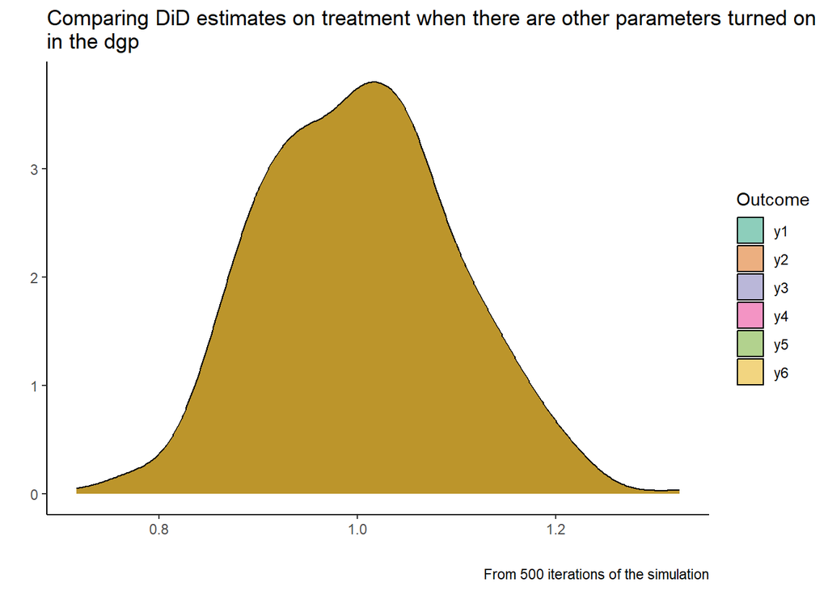

```r
generate_hist <- function(df, outcome, x_lab = ""){

estimate_df %>%
ggplot(data = ., aes(x = {{outcome}}, fill = outcome)) +
  geom_density(alpha = 0.5) +
  theme_classic() +
  labs(
    x = x_lab,
    y = "",
    title = str_wrap("Comparing DiD estimates on treatment when there are other parameters turned on in the dgp", 80),
    fill = "Outcome",
    caption = paste0("From ",n_iter," iterations of the simulation")
    #subtitle = str_wrap("The average standard error estimate from DiD is smaller than TWFE, except when the error sutructure has only e_t and e_it componenets.", 80)

    ) +
  scale_fill_manual(values = RColorBrewer::brewer.pal(8, "Dark2")) +
  scale_color_manual(values = RColorBrewer::brewer.pal(8, "Dark2")) +
    guides(color = "none")
}


generate_hist(estimate_df,
              outcome = estimate)
```

The estimate of the mean is exactly identical.

**Part 4.** Demonstrate the implications of $\sigma$ (i.e., on $\hat\beta_3$ and associated standard-error estimates).

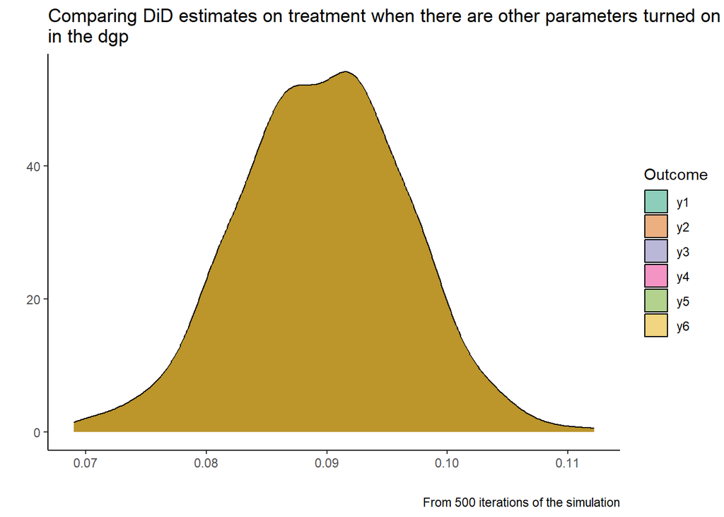

```r
generate_hist(estimate_df,
              outcome = std.error)
```

The estimates and standard errors (clustered at individual level) are exactly identical.